# What is Emotional Containment? | Oxford CBT

[figure not shown]

# What is Emotional Containment?

- [February 18, 2022](https://www.oxfordcbt.co.uk/2022/02/18/)

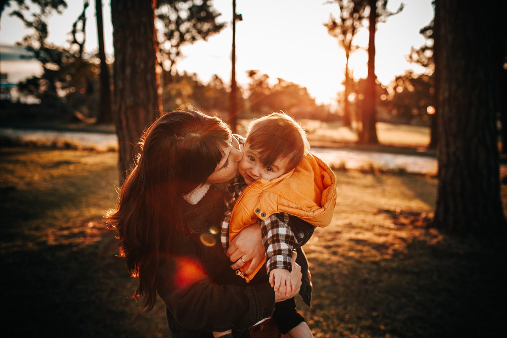

As young children, we experience extremely strong emotions, and we have to learn to deal with them in a healthy way so that we can learn to live and work alongside others. This is known as **emotional containment**. Also, when we are young we need to feel that our emotions are recognised and understood by an adult, who can then contain them for us. This understanding can continue into our adult life and is still as important when we are an adult, as when we were a child. This article looks at what emotional containment is, the effects a lack of emotional containment can cause, and how to [support children](http://oxfordcbt.co.uk/support-for-children/) with learning to contain their emotions.

## **What is Emotional Containment?**

Emotional containment describes the process of emotionally helping people to bring about support and change. This support can benefit all children and is particularly helpful for children who experience social, emotional and [mental health](http://oxfordcbt.co.uk/mental-health/) (SEMH) needs. Emotional containment can also be helpful when dealing with adults who also suffer from SEMH needs.

The concept of containment refers to an experience of feeling held and protected, both in a physical and emotional sense. Psychologists relate this experience back to birth and the relationship between a mother and a child. When a baby cries or is distressed, the mother (or main carer) will respond to those needs and replace the emotional despair with something comforting. Examples of this would include changing the baby’s nappy, giving a cuddle or feeding the baby.

The past 2 years have taken away emotional containment for a lot of people. In a time of a global pandemic, the ability to physically be with other people, sharing the same experience and supporting each other was taken away from us. Many of us, unfortunately, experienced the death of loved ones and were unable to properly grieve that loss. Being part of a group can offer us support and strength when dealing with our emotions, but we have missed this during these strange and difficult times. As adults, we need emotional containment as much as our children, especially when faced with a challenge.

## **What Effects Can Lack Of Emotional Containment Cause?**

As children, if we are deprived of emotional containment, or are not exposed to it consistently and properly, then this is going to have detrimental effects in later years. Long-term, if unsupported, children may:

- have a difficulty/inability to recognise/feel their own emotions
- have disrupted sleep/eating patterns
- develop compulsive behaviours
- be vulnerable to addiction
- experience [panic attacks](http://oxfordcbt.co.uk/cbttherapy/panic-attacks/)
- experience anxiety
- develop [low self-esteem](http://oxfordcbt.co.uk/cbttherapy/low-self-esteem/)
- lack of ability to express their own needs
- feeling undeserving of having their needs met
- develop a negative sense of self / their self-worth
- develop separation anxiety

The purpose of emotional containment is often described as helping to hold the person together. At times, the want to provide this can feel instinctive, whilst at other times children might communicate in a way that tries to push you away from them. Children who have received a lack of emotional containment can find the feelings that get triggered by a situation (whether it is a true event or a thought one), more intense. This will be due to the pain of unresolved feelings from the past that will also be being triggered in this situation. Their underdeveloped ability to manage these more intense feelings will also make it more likely for them to become overwhelmed and distressed.

## **How Can I Support a Child with Their Emotional Needs?**

To support a child’s emotional development, adults need to help the child to learn that it is safe to feel difficult emotions. Adults can also give real-life examples of how they manage their emotional expression as this shows to the child that having strong feelings does not have to have a bad impact on the people around us. When a child is shouting and raging about a toy that they want but cannot have, they are looking to the adult to learn how to deal and cope with this situation. If the adult shouts and screams back, the child learns that this is how to express their emotions and the behaviour will repeat.

When a child is becoming overwhelmed or distressed with their emotions, a containing adult will communicate with the child. Instead of putting the child down and showing them that their emotions are wrong, the adult will explain to the child that they know how they are feeling and that it feels bad. An example of how to word this might be:

### Feelings Of Anger

*You feel really angry that I did not let you have the toy. I understand you feel really angry with me because you wanted that toy so much. Mummy didn’t let you have it because it is not safe for you to play with, it might hurt you, and I don’t want you to be hurt. Why don’t you play with this instead? I know you feel angry and frustrated, but it is ok. This is a bad feeling, but we can move on, and we are not going to allow it to spoil the whole day.*

Although this may seem like a lot of words, and the child may not be at an age where they can understand all of what the adult is saying, but the importance is in the tone of voice. As mentioned before, the child will be looking to learn from the adult and the attitude and state of mind of the adult will be picked up on by the child and will be referred to at another time. Children will notice if adults are consistent with this containment and may even test the adult to see if the adult will be there to contain them emotionally again and again.

Emotional containment is essentially about providing children with space, support, safety and clear and consistent boundaries to allow them to express their emotions but also to keep them and others safe.

All clinicians at [Oxford CBT](http://oxfordcbt.co.uk/) practice [Cognitive Behavioural Therapy](http://oxfordcbt.co.uk/), or are Psychologists, providing evidence-based interventions and support for a range of issues for both young people and adults. If you would like to book an appointment you can do so on our [**online booking portal**](https://herohealth.net/practice-locations/oxford-cbt). If you have a question please get in touch via our [**online contact form**](http://oxfordcbt.co.uk/getintouch/) or call us on 01865 920077.

[figure not shown]